# Risk Factor Analysis

## Outcome Variable

**Outcome Variable:** ever_stunted

## Predictor Variables

**Intervention Variable:** month

**Adjustment Set:**

unadjusted

## Stratifying Variables

The analysis was stratified on these variable(s):

- agecat
- studyid
- country

## Data Summary

| agecat | studyid | country | month | ever_stunted | n_cell | n |
| --- | --- | --- | --- | --- | --- | --- |
| 0-24 months (no birth st.) | CMC-V-BCS-2002 | INDIA | 1 | 0 | 1 | 296 |
| 0-24 months (no birth st.) | CMC-V-BCS-2002 | INDIA | 1 | 1 | 17 | 296 |
| 0-24 months (no birth st.) | CMC-V-BCS-2002 | INDIA | 2 | 0 | 1 | 296 |
| 0-24 months (no birth st.) | CMC-V-BCS-2002 | INDIA | 2 | 1 | 14 | 296 |
| 0-24 months (no birth st.) | CMC-V-BCS-2002 | INDIA | 3 | 0 | 0 | 296 |
| 0-24 months (no birth st.) | CMC-V-BCS-2002 | INDIA | 3 | 1 | 22 | 296 |
| 0-24 months (no birth st.) | CMC-V-BCS-2002 | INDIA | 4 | 0 | 2 | 296 |
| 0-24 months (no birth st.) | CMC-V-BCS-2002 | INDIA | 4 | 1 | 22 | 296 |
| 0-24 months (no birth st.) | CMC-V-BCS-2002 | INDIA | 5 | 0 | 5 | 296 |
| 0-24 months (no birth st.) | CMC-V-BCS-2002 | INDIA | 5 | 1 | 36 | 296 |
| 0-24 months (no birth st.) | CMC-V-BCS-2002 | INDIA | 6 | 0 | 3 | 296 |
| 0-24 months (no birth st.) | CMC-V-BCS-2002 | INDIA | 6 | 1 | 28 | 296 |
| 0-24 months (no birth st.) | CMC-V-BCS-2002 | INDIA | 7 | 0 | 5 | 296 |
| 0-24 months (no birth st.) | CMC-V-BCS-2002 | INDIA | 7 | 1 | 25 | 296 |
| 0-24 months (no birth st.) | CMC-V-BCS-2002 | INDIA | 8 | 0 | 2 | 296 |
| 0-24 months (no birth st.) | CMC-V-BCS-2002 | INDIA | 8 | 1 | 30 | 296 |
| 0-24 months (no birth st.) | CMC-V-BCS-2002 | INDIA | 9 | 0 | 2 | 296 |
| 0-24 months (no birth st.) | CMC-V-BCS-2002 | INDIA | 9 | 1 | 12 | 296 |
| 0-24 months (no birth st.) | CMC-V-BCS-2002 | INDIA | 10 | 0 | 0 | 296 |
| 0-24 months (no birth st.) | CMC-V-BCS-2002 | INDIA | 10 | 1 | 14 | 296 |
| 0-24 months (no birth st.) | CMC-V-BCS-2002 | INDIA | 11 | 0 | 5 | 296 |
| 0-24 months (no birth st.) | CMC-V-BCS-2002 | INDIA | 11 | 1 | 28 | 296 |
| 0-24 months (no birth st.) | CMC-V-BCS-2002 | INDIA | 12 | 0 | 2 | 296 |
| 0-24 months (no birth st.) | CMC-V-BCS-2002 | INDIA | 12 | 1 | 20 | 296 |
| 0-24 months (no birth st.) | CMIN | BANGLADESH | 1 | 0 | 2 | 168 |
| 0-24 months (no birth st.) | CMIN | BANGLADESH | 1 | 1 | 13 | 168 |
| 0-24 months (no birth st.) | CMIN | BANGLADESH | 2 | 0 | 6 | 168 |
| 0-24 months (no birth st.) | CMIN | BANGLADESH | 2 | 1 | 15 | 168 |
| 0-24 months (no birth st.) | CMIN | BANGLADESH | 3 | 0 | 6 | 168 |
| 0-24 months (no birth st.) | CMIN | BANGLADESH | 3 | 1 | 10 | 168 |

[output cut: 1194 more lines]

The following strata were considered:

- agecat: 0-24 months (no birth st.), studyid: CMC-V-BCS-2002, country: INDIA
- agecat: 0-24 months (no birth st.), studyid: CMIN, country: BANGLADESH
- agecat: 0-24 months (no birth st.), studyid: CONTENT, country: PERU
- agecat: 0-24 months (no birth st.), studyid: EE, country: PAKISTAN
- agecat: 0-24 months (no birth st.), studyid: GMS-Nepal, country: NEPAL
- agecat: 0-24 months (no birth st.), studyid: Guatemala BSC, country: GUATEMALA
- agecat: 0-24 months (no birth st.), studyid: iLiNS-Zinc, country: BURKINA FASO
- agecat: 0-24 months (no birth st.), studyid: IRC, country: INDIA
- agecat: 0-24 months (no birth st.), studyid: JiVitA-3, country: BANGLADESH
- agecat: 0-24 months (no birth st.), studyid: JiVitA-4, country: BANGLADESH
- agecat: 0-24 months (no birth st.), studyid: Keneba, country: GAMBIA
- agecat: 0-24 months (no birth st.), studyid: LCNI-5, country: MALAWI
- agecat: 0-24 months (no birth st.), studyid: MAL-ED, country: BANGLADESH
- agecat: 0-24 months (no birth st.), studyid: MAL-ED, country: BRAZIL
- agecat: 0-24 months (no birth st.), studyid: MAL-ED, country: INDIA
- agecat: 0-24 months (no birth st.), studyid: MAL-ED, country: NEPAL
- agecat: 0-24 months (no birth st.), studyid: MAL-ED, country: PERU
- agecat: 0-24 months (no birth st.), studyid: MAL-ED, country: SOUTH AFRICA
- agecat: 0-24 months (no birth st.), studyid: MAL-ED, country: TANZANIA, UNITED REPUBLIC OF
- agecat: 0-24 months (no birth st.), studyid: NIH-Birth, country: BANGLADESH
- agecat: 0-24 months (no birth st.), studyid: PROBIT, country: BELARUS
- agecat: 0-24 months (no birth st.), studyid: ResPak, country: PAKISTAN
- agecat: 0-24 months (no birth st.), studyid: SAS-CompFeed, country: INDIA
- agecat: 0-24 months (no birth st.), studyid: SAS-FoodSuppl, country: INDIA
- agecat: 0-24 months (no birth st.), studyid: TanzaniaChild2, country: TANZANIA, UNITED REPUBLIC OF
- agecat: 0-24 months (no birth st.), studyid: ZVITAMBO, country: ZIMBABWE
- agecat: 0-6 months (no birth st.), studyid: CMC-V-BCS-2002, country: INDIA
- agecat: 0-6 months (no birth st.), studyid: CMIN, country: BANGLADESH
- agecat: 0-6 months (no birth st.), studyid: CONTENT, country: PERU
- agecat: 0-6 months (no birth st.), studyid: EE, country: PAKISTAN
- agecat: 0-6 months (no birth st.), studyid: GMS-Nepal, country: NEPAL
- agecat: 0-6 months (no birth st.), studyid: Guatemala BSC, country: GUATEMALA
- agecat: 0-6 months (no birth st.), studyid: IRC, country: INDIA
- agecat: 0-6 months (no birth st.), studyid: JiVitA-3, country: BANGLADESH
- agecat: 0-6 months (no birth st.), studyid: JiVitA-4, country: BANGLADESH
- agecat: 0-6 months (no birth st.), studyid: Keneba, country: GAMBIA
- agecat: 0-6 months (no birth st.), studyid: LCNI-5, country: MALAWI
- agecat: 0-6 months (no birth st.), studyid: MAL-ED, country: BANGLADESH
- agecat: 0-6 months (no birth st.), studyid: MAL-ED, country: BRAZIL
- agecat: 0-6 months (no birth st.), studyid: MAL-ED, country: INDIA
- agecat: 0-6 months (no birth st.), studyid: MAL-ED, country: NEPAL
- agecat: 0-6 months (no birth st.), studyid: MAL-ED, country: PERU
- agecat: 0-6 months (no birth st.), studyid: MAL-ED, country: SOUTH AFRICA
- agecat: 0-6 months (no birth st.), studyid: MAL-ED, country: TANZANIA, UNITED REPUBLIC OF
- agecat: 0-6 months (no birth st.), studyid: NIH-Birth, country: BANGLADESH
- agecat: 0-6 months (no birth st.), studyid: PROBIT, country: BELARUS
- agecat: 0-6 months (no birth st.), studyid: ResPak, country: PAKISTAN
- agecat: 0-6 months (no birth st.), studyid: SAS-CompFeed, country: INDIA
- agecat: 0-6 months (no birth st.), studyid: SAS-FoodSuppl, country: INDIA
- agecat: 0-6 months (no birth st.), studyid: TanzaniaChild2, country: TANZANIA, UNITED REPUBLIC OF
- agecat: 0-6 months (no birth st.), studyid: ZVITAMBO, country: ZIMBABWE

### Dropped Strata

Some strata were dropped due to rare outcomes:

- agecat: 0-24 months (no birth st.), studyid: CMC-V-BCS-2002, country: INDIA
- agecat: 0-24 months (no birth st.), studyid: CMIN, country: BANGLADESH
- agecat: 0-24 months (no birth st.), studyid: CONTENT, country: PERU
- agecat: 0-24 months (no birth st.), studyid: EE, country: PAKISTAN
- agecat: 0-24 months (no birth st.), studyid: GMS-Nepal, country: NEPAL
- agecat: 0-24 months (no birth st.), studyid: Guatemala BSC, country: GUATEMALA
- agecat: 0-24 months (no birth st.), studyid: IRC, country: INDIA
- agecat: 0-24 months (no birth st.), studyid: MAL-ED, country: BANGLADESH
- agecat: 0-24 months (no birth st.), studyid: MAL-ED, country: BRAZIL
- agecat: 0-24 months (no birth st.), studyid: MAL-ED, country: INDIA
- agecat: 0-24 months (no birth st.), studyid: MAL-ED, country: NEPAL
- agecat: 0-24 months (no birth st.), studyid: MAL-ED, country: SOUTH AFRICA
- agecat: 0-24 months (no birth st.), studyid: MAL-ED, country: TANZANIA, UNITED REPUBLIC OF
- agecat: 0-24 months (no birth st.), studyid: ResPak, country: PAKISTAN
- agecat: 0-24 months (no birth st.), studyid: SAS-FoodSuppl, country: INDIA
- agecat: 0-6 months (no birth st.), studyid: CMC-V-BCS-2002, country: INDIA
- agecat: 0-6 months (no birth st.), studyid: CMIN, country: BANGLADESH
- agecat: 0-6 months (no birth st.), studyid: CONTENT, country: PERU
- agecat: 0-6 months (no birth st.), studyid: EE, country: PAKISTAN
- agecat: 0-6 months (no birth st.), studyid: GMS-Nepal, country: NEPAL
- agecat: 0-6 months (no birth st.), studyid: Guatemala BSC, country: GUATEMALA
- agecat: 0-6 months (no birth st.), studyid: JiVitA-4, country: BANGLADESH
- agecat: 0-6 months (no birth st.), studyid: LCNI-5, country: MALAWI
- agecat: 0-6 months (no birth st.), studyid: MAL-ED, country: BANGLADESH
- agecat: 0-6 months (no birth st.), studyid: MAL-ED, country: BRAZIL
- agecat: 0-6 months (no birth st.), studyid: MAL-ED, country: INDIA
- agecat: 0-6 months (no birth st.), studyid: MAL-ED, country: NEPAL
- agecat: 0-6 months (no birth st.), studyid: MAL-ED, country: PERU
- agecat: 0-6 months (no birth st.), studyid: MAL-ED, country: SOUTH AFRICA
- agecat: 0-6 months (no birth st.), studyid: MAL-ED, country: TANZANIA, UNITED REPUBLIC OF
- agecat: 0-6 months (no birth st.), studyid: ResPak, country: PAKISTAN
- agecat: 0-6 months (no birth st.), studyid: SAS-FoodSuppl, country: INDIA

## Methods Detail

We're interested in the causal parameters $E[Y_a]$ for all values of $a \in \mathcal{A}$. These parameters represent the mean outcome if, possibly contrary to fact, we intervened to set all units to have $A=a$. Under the randomization and positivity assumptions, these are identified by the statistical parameters $\psi_a=E_W[E_{Y|A,W}(Y|A=a,W)]$. In addition, we're interested in the mean of $Y$, $E[Y]$ under no intervention (the observed mean). We will estimate these parameters by using SuperLearner to fit the relevant likelihood factors -- $E_{Y|A,W}(Y|A=a,W)$ and $p(A=a|W)$, and then updating our likelihood fit using a joint TMLE.

For unadjusted analyses ($W=\{\}$), initial likelihoods were estimated using Lrnr_glm to estimate the simple $E(Y|A)$ and Lrnr_mean to estimate $p(A)$. For adjusted analyses, a small library containing Lrnr_glmnet, Lrnr_xgboost, and Lrnr_mean was used.

Having estimated these parameters, we will then use the delta method to estimate relative risks and attributable risks relative to a prespecified baseline level of $A$.

# Results Detail

## Results Plots

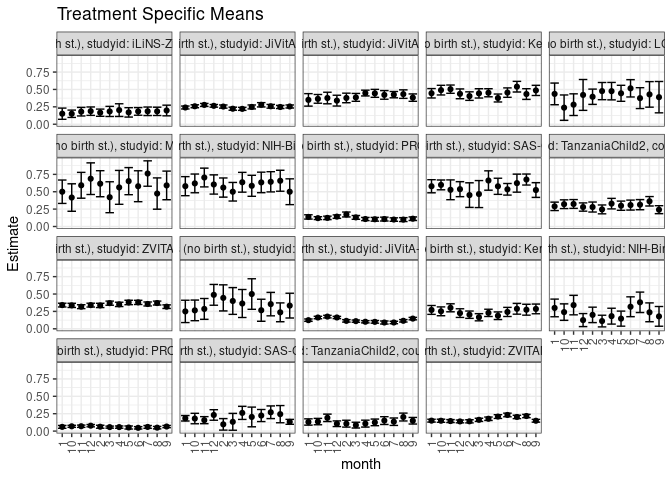

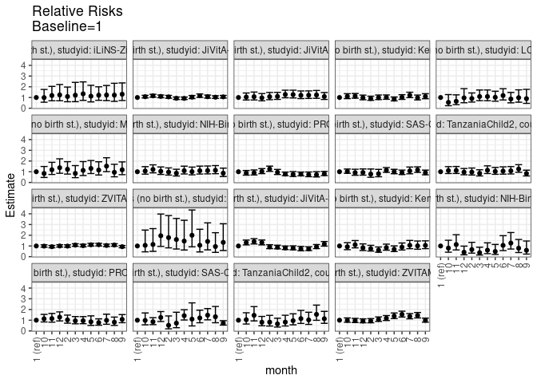

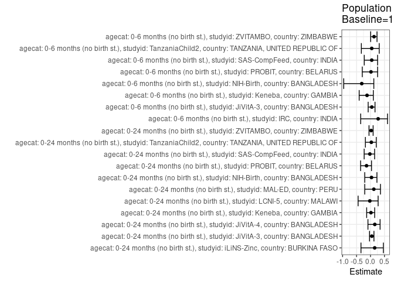

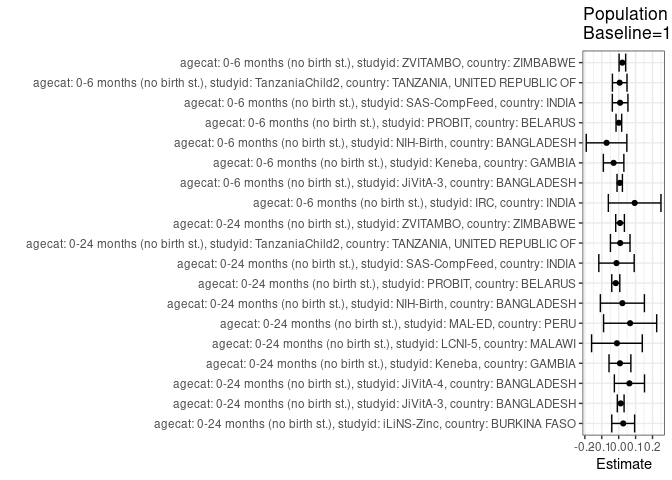

## Results Table

### Parameter: TSM

| agecat | studyid | country | intervention_level | baseline_level | estimate | ci_lower | ci_upper |
| --- | --- | --- | --- | --- | --- | --- | --- |
| 0-24 months (no birth st.) | iLiNS-Zinc | BURKINA FASO | 1 | NA | 0.1513514 | 0.0707045 | 0.2319982 |
| 0-24 months (no birth st.) | iLiNS-Zinc | BURKINA FASO | 2 | NA | 0.1655172 | 0.1135598 | 0.2174746 |
| 0-24 months (no birth st.) | iLiNS-Zinc | BURKINA FASO | 3 | NA | 0.1839080 | 0.1111824 | 0.2566337 |
| 0-24 months (no birth st.) | iLiNS-Zinc | BURKINA FASO | 4 | NA | 0.2027972 | 0.1115087 | 0.2940857 |
| 0-24 months (no birth st.) | iLiNS-Zinc | BURKINA FASO | 5 | NA | 0.1702128 | 0.1028189 | 0.2376066 |
| 0-24 months (no birth st.) | iLiNS-Zinc | BURKINA FASO | 6 | NA | 0.1840278 | 0.1291873 | 0.2388682 |
| 0-24 months (no birth st.) | iLiNS-Zinc | BURKINA FASO | 7 | NA | 0.1859756 | 0.1246588 | 0.2472924 |
| 0-24 months (no birth st.) | iLiNS-Zinc | BURKINA FASO | 8 | NA | 0.1850534 | 0.1253319 | 0.2447749 |
| 0-24 months (no birth st.) | iLiNS-Zinc | BURKINA FASO | 9 | NA | 0.1973094 | 0.1206905 | 0.2739283 |
| 0-24 months (no birth st.) | iLiNS-Zinc | BURKINA FASO | 10 | NA | 0.1500000 | 0.0971895 | 0.2028105 |
| 0-24 months (no birth st.) | iLiNS-Zinc | BURKINA FASO | 11 | NA | 0.1800000 | 0.1183049 | 0.2416951 |
| 0-24 months (no birth st.) | iLiNS-Zinc | BURKINA FASO | 12 | NA | 0.1875000 | 0.1269371 | 0.2480629 |
| 0-24 months (no birth st.) | JiVitA-3 | BANGLADESH | 1 | NA | 0.2402913 | 0.2189836 | 0.2615989 |
| 0-24 months (no birth st.) | JiVitA-3 | BANGLADESH | 2 | NA | 0.2537723 | 0.2304930 | 0.2770516 |
| 0-24 months (no birth st.) | JiVitA-3 | BANGLADESH | 3 | NA | 0.2227299 | 0.2008325 | 0.2446272 |
| 0-24 months (no birth st.) | JiVitA-3 | BANGLADESH | 4 | NA | 0.2207308 | 0.1991382 | 0.2423234 |
| 0-24 months (no birth st.) | JiVitA-3 | BANGLADESH | 5 | NA | 0.2484970 | 0.2204043 | 0.2765897 |
| 0-24 months (no birth st.) | JiVitA-3 | BANGLADESH | 6 | NA | 0.2793068 | 0.2483939 | 0.3102198 |
| 0-24 months (no birth st.) | JiVitA-3 | BANGLADESH | 7 | NA | 0.2576854 | 0.2309961 | 0.2843746 |
| 0-24 months (no birth st.) | JiVitA-3 | BANGLADESH | 8 | NA | 0.2476669 | 0.2247560 | 0.2705778 |
| 0-24 months (no birth st.) | JiVitA-3 | BANGLADESH | 9 | NA | 0.2549758 | 0.2331257 | 0.2768259 |
| 0-24 months (no birth st.) | JiVitA-3 | BANGLADESH | 10 | NA | 0.2580977 | 0.2369678 | 0.2792275 |
| 0-24 months (no birth st.) | JiVitA-3 | BANGLADESH | 11 | NA | 0.2776309 | 0.2561587 | 0.2991031 |
| 0-24 months (no birth st.) | JiVitA-3 | BANGLADESH | 12 | NA | 0.2643392 | 0.2449261 | 0.2837522 |
| 0-24 months (no birth st.) | JiVitA-4 | BANGLADESH | 1 | NA | 0.3500000 | 0.2599959 | 0.4400041 |
| 0-24 months (no birth st.) | JiVitA-4 | BANGLADESH | 2 | NA | 0.3775934 | 0.3090238 | 0.4461629 |
| 0-24 months (no birth st.) | JiVitA-4 | BANGLADESH | 3 | NA | 0.3859060 | 0.3294595 | 0.4423525 |
| 0-24 months (no birth st.) | JiVitA-4 | BANGLADESH | 4 | NA | 0.4481707 | 0.4065333 | 0.4898082 |
| 0-24 months (no birth st.) | JiVitA-4 | BANGLADESH | 5 | NA | 0.4439359 | 0.3870578 | 0.5008140 |
| 0-24 months (no birth st.) | JiVitA-4 | BANGLADESH | 6 | NA | 0.4213836 | 0.3592866 | 0.4834807 |

[output cut: 198 more lines]

### Parameter: E(Y)

| agecat | studyid | country | intervention_level | baseline_level | estimate | ci_lower | ci_upper |
| --- | --- | --- | --- | --- | --- | --- | --- |
| 0-24 months (no birth st.) | iLiNS-Zinc | BURKINA FASO | NA | NA | 0.1780497 | 0.1518612 | 0.2042383 |
| 0-24 months (no birth st.) | JiVitA-3 | BANGLADESH | NA | NA | 0.2522312 | 0.2444909 | 0.2599715 |
| 0-24 months (no birth st.) | JiVitA-4 | BANGLADESH | NA | NA | 0.4135358 | 0.3953404 | 0.4317312 |
| 0-24 months (no birth st.) | Keneba | GAMBIA | NA | NA | 0.4524085 | 0.4332546 | 0.4715624 |
| 0-24 months (no birth st.) | LCNI-5 | MALAWI | NA | NA | 0.4256121 | 0.3835181 | 0.4677060 |
| 0-24 months (no birth st.) | MAL-ED | PERU | NA | NA | 0.5676692 | 0.5080232 | 0.6273151 |
| 0-24 months (no birth st.) | NIH-Birth | BANGLADESH | NA | NA | 0.6018868 | 0.5601729 | 0.6436007 |
| 0-24 months (no birth st.) | PROBIT | BELARUS | NA | NA | 0.1205488 | 0.1047261 | 0.1363714 |
| 0-24 months (no birth st.) | SAS-CompFeed | INDIA | NA | NA | 0.5660550 | 0.5086421 | 0.6234680 |
| 0-24 months (no birth st.) | TanzaniaChild2 | TANZANIA, UNITED REPUBLIC OF | NA | NA | 0.2988814 | 0.2798990 | 0.3178639 |
| 0-24 months (no birth st.) | ZVITAMBO | ZIMBABWE | NA | NA | 0.3487098 | 0.3403867 | 0.3570329 |
| 0-6 months (no birth st.) | IRC | INDIA | NA | NA | 0.3444444 | 0.2952897 | 0.3935992 |
| 0-6 months (no birth st.) | JiVitA-3 | BANGLADESH | NA | NA | 0.1302640 | 0.1246817 | 0.1358464 |
| 0-6 months (no birth st.) | Keneba | GAMBIA | NA | NA | 0.2412713 | 0.2235253 | 0.2590172 |
| 0-6 months (no birth st.) | NIH-Birth | BANGLADESH | NA | NA | 0.2283019 | 0.1925336 | 0.2640702 |
| 0-6 months (no birth st.) | PROBIT | BELARUS | NA | NA | 0.0614448 | 0.0507274 | 0.0721623 |
| 0-6 months (no birth st.) | SAS-CompFeed | INDIA | NA | NA | 0.1928375 | 0.1691727 | 0.2165022 |
| 0-6 months (no birth st.) | TanzaniaChild2 | TANZANIA, UNITED REPUBLIC OF | NA | NA | 0.1369128 | 0.1226581 | 0.1511674 |
| 0-6 months (no birth st.) | ZVITAMBO | ZIMBABWE | NA | NA | 0.1718849 | 0.1652929 | 0.1784770 |

### Parameter: RR

| agecat | studyid | country | intervention_level | baseline_level | estimate | ci_lower | ci_upper |
| --- | --- | --- | --- | --- | --- | --- | --- |
| 0-24 months (no birth st.) | iLiNS-Zinc | BURKINA FASO | 1 | 1 | 1.0000000 | 1.0000000 | 1.0000000 |
| 0-24 months (no birth st.) | iLiNS-Zinc | BURKINA FASO | 2 | 1 | 1.0935961 | 0.6053648 | 1.9755895 |
| 0-24 months (no birth st.) | iLiNS-Zinc | BURKINA FASO | 3 | 1 | 1.2151067 | 0.6120015 | 2.4125503 |
| 0-24 months (no birth st.) | iLiNS-Zinc | BURKINA FASO | 4 | 1 | 1.3399101 | 0.7310123 | 2.4559903 |
| 0-24 months (no birth st.) | iLiNS-Zinc | BURKINA FASO | 5 | 1 | 1.1246201 | 0.5918309 | 2.1370467 |
| 0-24 months (no birth st.) | iLiNS-Zinc | BURKINA FASO | 6 | 1 | 1.2158978 | 0.7395621 | 1.9990308 |
| 0-24 months (no birth st.) | iLiNS-Zinc | BURKINA FASO | 7 | 1 | 1.2287674 | 0.7118924 | 2.1209237 |
| 0-24 months (no birth st.) | iLiNS-Zinc | BURKINA FASO | 8 | 1 | 1.2226741 | 0.6426225 | 2.3262989 |
| 0-24 months (no birth st.) | iLiNS-Zinc | BURKINA FASO | 9 | 1 | 1.3036515 | 0.7205591 | 2.3585953 |
| 0-24 months (no birth st.) | iLiNS-Zinc | BURKINA FASO | 10 | 1 | 0.9910714 | 0.5605672 | 1.7521942 |
| 0-24 months (no birth st.) | iLiNS-Zinc | BURKINA FASO | 11 | 1 | 1.1892857 | 0.6947181 | 2.0359343 |
| 0-24 months (no birth st.) | iLiNS-Zinc | BURKINA FASO | 12 | 1 | 1.2388393 | 0.6939323 | 2.2116318 |
| 0-24 months (no birth st.) | JiVitA-3 | BANGLADESH | 1 | 1 | 1.0000000 | 1.0000000 | 1.0000000 |
| 0-24 months (no birth st.) | JiVitA-3 | BANGLADESH | 2 | 1 | 1.0561029 | 0.9298029 | 1.1995589 |
| 0-24 months (no birth st.) | JiVitA-3 | BANGLADESH | 3 | 1 | 0.9269162 | 0.8162138 | 1.0526332 |
| 0-24 months (no birth st.) | JiVitA-3 | BANGLADESH | 4 | 1 | 0.9185969 | 0.8068974 | 1.0457589 |
| 0-24 months (no birth st.) | JiVitA-3 | BANGLADESH | 5 | 1 | 1.0341491 | 0.8972567 | 1.1919268 |
| 0-24 months (no birth st.) | JiVitA-3 | BANGLADESH | 6 | 1 | 1.1623678 | 1.0118593 | 1.3352637 |
| 0-24 months (no birth st.) | JiVitA-3 | BANGLADESH | 7 | 1 | 1.0723875 | 0.9370007 | 1.2273364 |
| 0-24 months (no birth st.) | JiVitA-3 | BANGLADESH | 8 | 1 | 1.0306946 | 0.9129238 | 1.1636583 |
| 0-24 months (no birth st.) | JiVitA-3 | BANGLADESH | 9 | 1 | 1.0611114 | 0.9410691 | 1.1964662 |
| 0-24 months (no birth st.) | JiVitA-3 | BANGLADESH | 10 | 1 | 1.0741035 | 0.9560513 | 1.2067326 |
| 0-24 months (no birth st.) | JiVitA-3 | BANGLADESH | 11 | 1 | 1.1553932 | 1.0275286 | 1.2991691 |
| 0-24 months (no birth st.) | JiVitA-3 | BANGLADESH | 12 | 1 | 1.1000781 | 0.9802316 | 1.2345774 |
| 0-24 months (no birth st.) | JiVitA-4 | BANGLADESH | 1 | 1 | 1.0000000 | 1.0000000 | 1.0000000 |
| 0-24 months (no birth st.) | JiVitA-4 | BANGLADESH | 2 | 1 | 1.0788382 | 0.7920960 | 1.4693823 |
| 0-24 months (no birth st.) | JiVitA-4 | BANGLADESH | 3 | 1 | 1.1025887 | 0.8226135 | 1.4778529 |
| 0-24 months (no birth st.) | JiVitA-4 | BANGLADESH | 4 | 1 | 1.2804878 | 0.9741769 | 1.6831122 |
| 0-24 months (no birth st.) | JiVitA-4 | BANGLADESH | 5 | 1 | 1.2683884 | 0.9572657 | 1.6806295 |
| 0-24 months (no birth st.) | JiVitA-4 | BANGLADESH | 6 | 1 | 1.2039533 | 0.8986757 | 1.6129329 |

[output cut: 198 more lines]

### Parameter: PAR

| agecat | studyid | country | intervention_level | baseline_level | estimate | ci_lower | ci_upper |
| --- | --- | --- | --- | --- | --- | --- | --- |
| 0-24 months (no birth st.) | iLiNS-Zinc | BURKINA FASO | 1 | NA | 0.0266984 | -0.0408889 | 0.0942857 |
| 0-24 months (no birth st.) | JiVitA-3 | BANGLADESH | 1 | NA | 0.0119399 | -0.0079978 | 0.0318776 |
| 0-24 months (no birth st.) | JiVitA-4 | BANGLADESH | 1 | NA | 0.0635358 | -0.0255710 | 0.1526426 |
| 0-24 months (no birth st.) | Keneba | GAMBIA | 1 | NA | 0.0074324 | -0.0571937 | 0.0720585 |
| 0-24 months (no birth st.) | LCNI-5 | MALAWI | 1 | NA | -0.0102854 | -0.1601958 | 0.1396251 |
| 0-24 months (no birth st.) | MAL-ED | PERU | 1 | NA | 0.0676692 | -0.0893729 | 0.2247112 |
| 0-24 months (no birth st.) | NIH-Birth | BANGLADESH | 1 | NA | 0.0218868 | -0.1083173 | 0.1520909 |
| 0-24 months (no birth st.) | PROBIT | BELARUS | 1 | NA | -0.0172063 | -0.0409978 | 0.0065851 |
| 0-24 months (no birth st.) | SAS-CompFeed | INDIA | 1 | NA | -0.0128923 | -0.1175040 | 0.0917193 |
| 0-24 months (no birth st.) | TanzaniaChild2 | TANZANIA, UNITED REPUBLIC OF | 1 | NA | 0.0091618 | -0.0487021 | 0.0670257 |
| 0-24 months (no birth st.) | ZVITAMBO | ZIMBABWE | 1 | NA | 0.0080874 | -0.0175632 | 0.0337381 |
| 0-6 months (no birth st.) | IRC | INDIA | 1 | NA | 0.0944444 | -0.0611166 | 0.2500055 |
| 0-6 months (no birth st.) | JiVitA-3 | BANGLADESH | 1 | NA | 0.0061009 | -0.0098274 | 0.0220292 |
| 0-6 months (no birth st.) | Keneba | GAMBIA | 1 | NA | -0.0300053 | -0.0906348 | 0.0306241 |
| 0-6 months (no birth st.) | NIH-Birth | BANGLADESH | 1 | NA | -0.0716981 | -0.1916734 | 0.0482772 |
| 0-6 months (no birth st.) | PROBIT | BELARUS | 1 | NA | 0.0010707 | -0.0155973 | 0.0177387 |
| 0-6 months (no birth st.) | SAS-CompFeed | INDIA | 1 | NA | 0.0086269 | -0.0375267 | 0.0547806 |
| 0-6 months (no birth st.) | TanzaniaChild2 | TANZANIA, UNITED REPUBLIC OF | 1 | NA | 0.0060716 | -0.0369911 | 0.0491344 |
| 0-6 months (no birth st.) | ZVITAMBO | ZIMBABWE | 1 | NA | 0.0218006 | 0.0023387 | 0.0412626 |

### Parameter: PAF

| agecat | studyid | country | intervention_level | baseline_level | estimate | ci_lower | ci_upper |
| --- | --- | --- | --- | --- | --- | --- | --- |
| 0-24 months (no birth st.) | iLiNS-Zinc | BURKINA FASO | 1 | NA | 0.1499491 | -0.3416600 | 0.4614235 |
| 0-24 months (no birth st.) | JiVitA-3 | BANGLADESH | 1 | NA | 0.0473372 | -0.0350772 | 0.1231896 |
| 0-24 months (no birth st.) | JiVitA-4 | BANGLADESH | 1 | NA | 0.1536403 | -0.0914265 | 0.3436803 |
| 0-24 months (no birth st.) | Keneba | GAMBIA | 1 | NA | 0.0164285 | -0.1373161 | 0.1493896 |
| 0-24 months (no birth st.) | LCNI-5 | MALAWI | 1 | NA | -0.0241661 | -0.4445459 | 0.2738782 |
| 0-24 months (no birth st.) | MAL-ED | PERU | 1 | NA | 0.1192053 | -0.2063217 | 0.3568886 |
| 0-24 months (no birth st.) | NIH-Birth | BANGLADESH | 1 | NA | 0.0363636 | -0.2062033 | 0.2301505 |
| 0-24 months (no birth st.) | PROBIT | BELARUS | 1 | NA | -0.1427334 | -0.3550467 | 0.0363138 |
| 0-24 months (no birth st.) | SAS-CompFeed | INDIA | 1 | NA | -0.0227757 | -0.2265857 | 0.1471691 |
| 0-24 months (no birth st.) | TanzaniaChild2 | TANZANIA, UNITED REPUBLIC OF | 1 | NA | 0.0306536 | -0.1836331 | 0.2061456 |
| 0-24 months (no birth st.) | ZVITAMBO | ZIMBABWE | 1 | NA | 0.0231924 | -0.0532070 | 0.0940499 |
| 0-6 months (no birth st.) | IRC | INDIA | 1 | NA | 0.2741935 | -0.3515036 | 0.6102156 |
| 0-6 months (no birth st.) | JiVitA-3 | BANGLADESH | 1 | NA | 0.0468349 | -0.0836639 | 0.1616186 |
| 0-6 months (no birth st.) | Keneba | GAMBIA | 1 | NA | -0.1243635 | -0.4058917 | 0.1007891 |
| 0-6 months (no birth st.) | NIH-Birth | BANGLADESH | 1 | NA | -0.3140496 | -0.9594055 | 0.1187499 |
| 0-6 months (no birth st.) | PROBIT | BELARUS | 1 | NA | 0.0174254 | -0.2952770 | 0.2546360 |
| 0-6 months (no birth st.) | SAS-CompFeed | INDIA | 1 | NA | 0.0447368 | -0.2236159 | 0.2542368 |
| 0-6 months (no birth st.) | TanzaniaChild2 | TANZANIA, UNITED REPUBLIC OF | 1 | NA | 0.0443467 | -0.3280842 | 0.3123379 |
| 0-6 months (no birth st.) | ZVITAMBO | ZIMBABWE | 1 | NA | 0.1268326 | 0.0060128 | 0.2329667 |